# IDS 575 Project

## Objectives

The data is related with direct marketing campaigns (phone calls) of a Portuguese banking institution. The classification goal is to predict if the client will subscribe a term deposit (variable y). We have to know first what are the factors that affect the decision of the customers. Then, we can use those variables to classify if which customers would subscribe the deposits and which customers would not. The steps of finding the best model to predict whether the client will subscribe a term deposit or not as follows:

### Bank client data:

1. age
2. job : type of job (categorical: ‘admin.’,‘blue-collar’,‘entrepreneur’,‘housemaid’,‘management’,‘retired’,‘self-employed’,‘services’,‘student’,‘technician’,‘unemployed’,‘unknown’)
3. marital : marital status (categorical: ‘divorced’,‘married’,‘single’,‘unknown’; note: ‘divorced’ means divorced or widowed)
4. education (categorical: ‘basic.4y’,‘basic.6y’,‘basic.9y’,‘high.school’,‘illiterate’,‘professional.course’,‘university.degree’,‘unknown’)
5. default: has credit in default? (categorical: ‘no’,‘yes’,‘unknown’)
6. housing: has housing loan? (categorical: ‘no’,‘yes’,‘unknown’)
7. loan: has personal loan? (categorical: ‘no’,‘yes’,‘unknown’)

### Related with the last contact of the current campaign:

8. contact: contact communication type (categorical: ‘cellular’,‘telephone’)
9. month: last contact month of year (categorical: ‘jan’, ‘feb’, ‘mar’, …, ‘nov’, ‘dec’)
10. day_of_week: last contact day of the week (categorical: ‘mon’,‘tue’,‘wed’,‘thu’,‘fri’)
11. duration: last contact duration, in seconds (numeric). Important note: this attribute highly affects the output target (e.g., if duration=0 then y=‘no’). Yet, the duration is not known before a call is performed.

### Other attributes:

12. campaign: number of contacts performed during this campaign and for this client (numeric, includes last contact)
13. pdays: number of days that passed by after the client was last contacted from a previous campaign (numeric; 999 means client was not previously contacted)
14. previous: number of contacts performed before this campaign and for this client (numeric)
15. poutcome: outcome of the previous marketing campaign (categorical: ‘failure’,‘nonexistent’,‘success’)

### Social and economic context attributes

16. emp.var.rate: employment variation rate - quarterly indicator (numeric)
17. cons.price.idx: consumer price index - monthly indicator (numeric)
18. cons.conf.idx: consumer confidence index - monthly indicator (numeric)
19. euribor3m: euribor 3 month rate - daily indicator (numeric)
20. nr.employed: number of employees - quarterly indicator (numeric) ###Output variable (desired target):
21. y - has the client subscribed a term deposit? (binary: ‘yes’,‘no’)

### Linear regression

I use linear regression to find out which parameters have direct relationpship with the variable y which is a term deposit.

- Forward stepwise selection is used to get the best variables affecting variable y the most.
- Here are the statiscally signicant variables:

duration, nr.employe,pdays, month, cons.conf.idx, poutcome, previous, contact,ons.price.idx, education, emp.var.rate

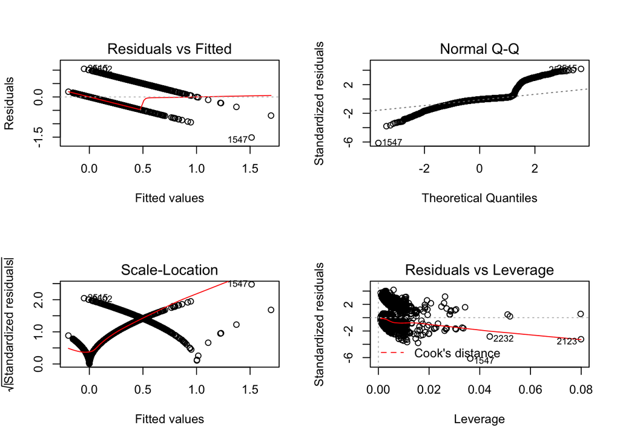

- According to the graphs, we can see that linear regression may not be appropriate to use for classifying variable y.

### Logistic regression

Since variable y is a nominal variable (0 and 1), it is better to use logistic regression to make a classification. First of all, we have divided data into two sets, training and test data. Also, we have to find which variables are statistically significant to variable y. We use the same method as mentioned.

```
##
## Call:
## glm(formula = y ~ duration + nr.employed + pdays + month + cons.conf.idx +
##     contact + poutcome + campaign, family = binomial, data = bank.train)
##
## Deviance Residuals:
##     Min       1Q   Median       3Q      Max
## -3.2310  -0.3099  -0.1895  -0.1342   3.2150
##
## Coefficients:
##                 Estimate Std. Error z value Pr(>|z|)
## (Intercept)   73.5660584  5.5557111  13.242  < 2e-16 ***
## duration       0.0048478  0.0002840  17.071  < 2e-16 ***
## nr.employed   -0.0143274  0.0011329 -12.647  < 2e-16 ***
## pdays         -0.0010306  0.0003359  -3.068 0.002157 **
## month         -0.1048532  0.0315364  -3.325 0.000885 ***
## cons.conf.idx  0.0548888  0.0137879   3.981 6.86e-05 ***
## contact       -0.6687131  0.2208638  -3.028 0.002464 **
## poutcome       0.4304628  0.1931257   2.229 0.025819 *
## campaign      -0.0312847  0.0455684  -0.687 0.492370
## ---
## Signif. codes:  0 '***' 0.001 '**' 0.01 '*' 0.05 '.' 0.1 ' ' 1
##
## (Dispersion parameter for binomial family taken to be 1)
##
##     Null deviance: 1987.4  on 2893  degrees of freedom
## Residual deviance: 1186.7  on 2885  degrees of freedom
## AIC: 1204.7
##
## Number of Fisher Scoring iterations: 6
```

```
##
## bank.glm.pred    0    1
##             0 2518  186
##             1   62  128
```

```
##
## data.glm.pred    0    1
##             0 2236  316
##             1  339 1905
```

- From the above confusion matrix. we can see that we have got a better model after adding more rows having varible y. I used cross validation to find the more precise error rate of this model, which is 0.0983669 The over all accuracy is 86.34 percent, considered very high and the specificity is now 0.8577

```
##
## data.glm.test.pred   0   1
##                  0 859 738
##                  1 234 198
```

### Decision Tree

Decision tree is used to predict qualitative response. Rpart package is used for constructing the model. First of all, I use only cp equal 0 so that the tree is fully grown and I find the minimum error and select cp later.

```
##          Actual
## Predicted    0    1
##         0 2233  133
##         1  342 2088
```

```
##          Actual
## Predicted   0   1
##         0 922  63
##         1 171 873
```

### Bagging method

- Bagging can improve predictions for many regression methods. I used 500 number of trees for growing the model and use the number of columns which is 20 for paramenter “mtry”

```
##          Actual
## Predicted    0    1
##         0 2575    0
##         1    0 2221
```

- From the confusion matrix above, we can see that the model can predict y equal to 1 as well as 0 correctly. Therefore, the specificity rate is 1

```
##          Actual
## Predicted    0    1
##         0 1003    0
##         1   90  936
```

### Random Forests

Random forests provide an improvement over bagged trees by way of a random small tweak that decorrelates the trees. The split is allowed to use only one of those m predictors. A fresh sample of m predictors is taken at each split, and typically we choose m equivalent $\sqrt{p}$. Therefore, for this data set, m is around 4.5825757

```
##          Actual
## Predicted    0    1
##         0 2574    0
##         1    1 2221
```

- We can see that random forest could give 100 percent of accuracy, recall, as well as specificity rates.

```
##          Actual
## Predicted    0    1
##         0 1001    0
##         1   92  936
```

### Boosting

The term ‘Boosting’ refers to a family of algorithms which converts weak learner to strong learners.It works on similar method as discussed above. It fits a sequence of weak learners on different weighted training data. It starts by predicting original data set and gives equal weight to each observation. If prediction is incorrect using the first learner, then it gives higher weight to observation which have been predicted incorrectly.

```
##                Observed Class
## Predicted Class    0    1
##               0 2575    0
##               1    0 2221
```

- Adaboost or boosting can make a classification of variable y almost perfectly

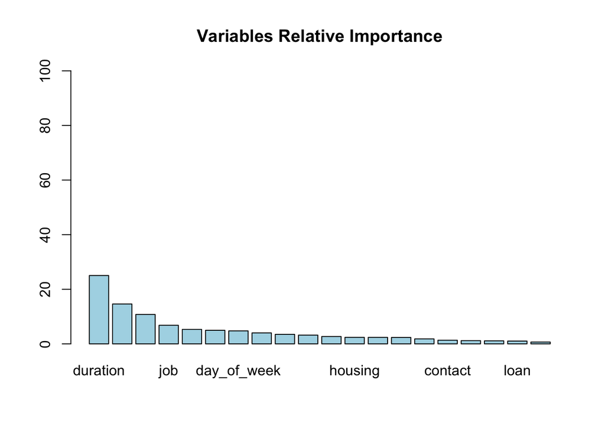

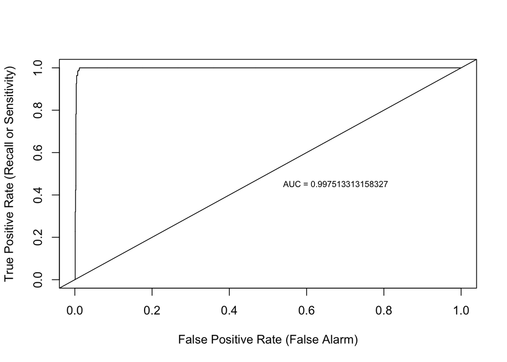

- We can see that which varaibles are the most important, which affects the decision to subscribe the program or the y variable.
- The second graph is AUC graph whic the x axis represents False Postive Rate and they axis is True Positive Rate or Recall rate. AUC is approximatlely 0.99. This shows that this model could possibly classify the variable y perfectly

### SVM

A support vector machine is a classification method. Its principle is fitting a boundary to a region of points which are all alike (that is, belong to one class). Once a boundary is fitted (on the training sample), for any new points (test sample) that need to be classified, we must simply check whether they lie inside the boundary or not.

- Advantage The advantage of SVM is that once a boundary is established, most of the training data is redundant. All it needs is a core set of points which can help identify and set the boundary. These data points are called support vectors because they “support” the boundary.

```
##
##        0    1
##   0 2575    0
##   1    0 2221
```

- We can see that support vector machine for the training data could classify the the data into two classes completely.
- Then, we will try this model with the test data.

```
##
## prd    0    1
##   0 1091    0
##   1    2  936
```

- The test data is almost perfectly classified. It could classify y equal to 1 perfectly.

### Hypothesis

- H1: Loan has no direct effect on the customer’s decision of a subscription on a term of deposit.

```
##               Df Sum Sq Mean Sq F value Pr(>F)
## loan           1    0.7  0.7141   2.873 0.0901 .
## Residuals   6823 1696.0  0.2486
## ---
## Signif. codes:  0 '***' 0.001 '**' 0.01 '*' 0.05 '.' 0.1 ' ' 1
```

```
##               Df Sum Sq Mean Sq F value Pr(>F)
## education      1   19.8  19.848   80.76 <2e-16 ***
## Residuals   6823 1676.8   0.246
## ---
## Signif. codes:  0 '***' 0.001 '**' 0.01 '*' 0.05 '.' 0.1 ' ' 1
```